# Proyecto N° 1

### **17. Estado Siniestro:**

#### **Frecuencia Absoluta y Frecuencia Relativa**

```r
# if (require("modeest")) install.packages("modeest")
library('modeest')
paste('Moda = ', mlv(DatosSegurosModelo$Estado_Siniestro, method = "mfv", na.rm = T))
```

```
## [1] "Moda =  no"
```

```r
table(DatosSegurosModelo$Estado_Siniestro)
```

```
##
##   no   si
## 4236  496
```

```r
round(table(DatosSegurosModelo$Estado_Siniestro) / nrow(DatosSegurosModelo) * 100, 2)
```

```
##
##    no    si
## 89.52 10.48
```

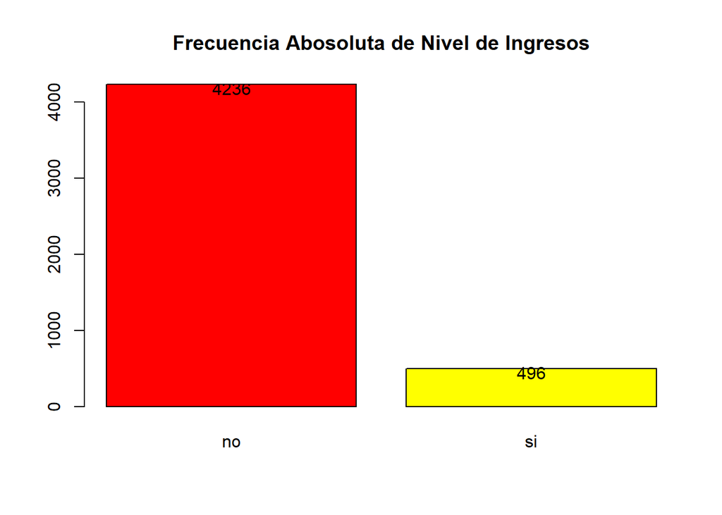

```r
a <- barplot(table(DatosSegurosModelo$Estado_Siniestro), main = 'Frecuencia Abosoluta de Nivel de Ingresos', col = rainbow(6))
text(a, table(DatosSegurosModelo$Estado_Siniestro) - 50, labels = table(DatosSegurosModelo$Estado_Siniestro))
```

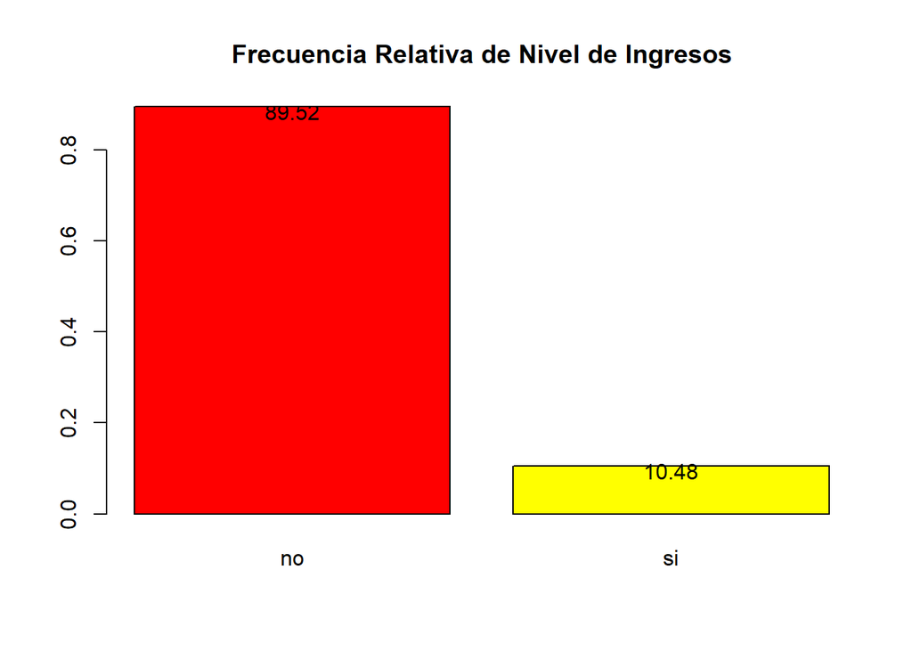

```r
b <- barplot(prop.table(table(DatosSegurosModelo$Estado_Siniestro)), main = 'Frecuencia Relativa de Nivel de Ingresos', col = rainbow(6))
text(b, prop.table(table(DatosSegurosModelo$Estado_Siniestro)) - 0.01, labels = round(prop.table(table(DatosSegurosModelo$Estado_Siniestro)), 4)*100)
```

#### **Versus Variables Continuas**

###### **Estado_Siniestro vs Antigüedad_Maxima**

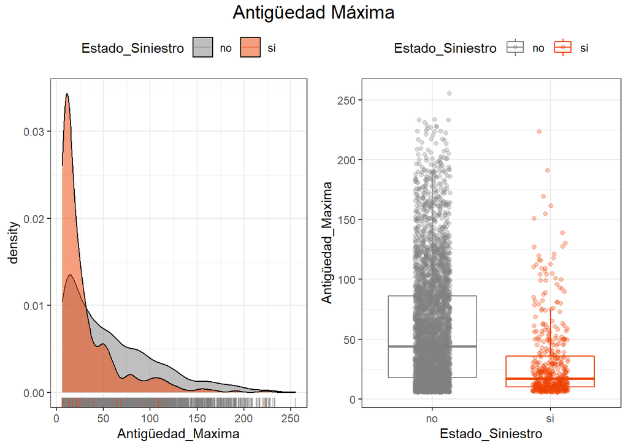

```r
# if (require("ggplot2")) install.packages("ggplot2")
# if (require("ggpubr")) install.packages("ggpubr")
library(ggplot2)
library(ggpubr)
p1 <- ggplot(data = DatosSegurosModelo, aes(x = Antigüedad_Maxima, fill = Estado_Siniestro)) +
      geom_density(alpha = 0.5) +
      scale_fill_manual(values = c("gray50", "orangered2")) +
      geom_rug(aes(color = Estado_Siniestro), alpha = 0.5) +
      scale_color_manual(values = c("gray50", "orangered2")) +
      theme_bw()
p2 <- ggplot(data = DatosSegurosModelo, aes(x = Estado_Siniestro, y = Antigüedad_Maxima, color = Estado_Siniestro)) +
      geom_boxplot(outlier.shape = NA) +
      geom_jitter(alpha = 0.3, width = 0.15) +
      scale_color_manual(values = c("gray50", "orangered2")) +
      theme_bw()
final_plot <- ggarrange(p1, p2, legend = "top")
final_plot <- annotate_figure(final_plot, top = text_grob("Antigüedad Máxima", size = 15))
final_plot
```

###### **Estado_Siniestro vs Saldo_Pendiente**

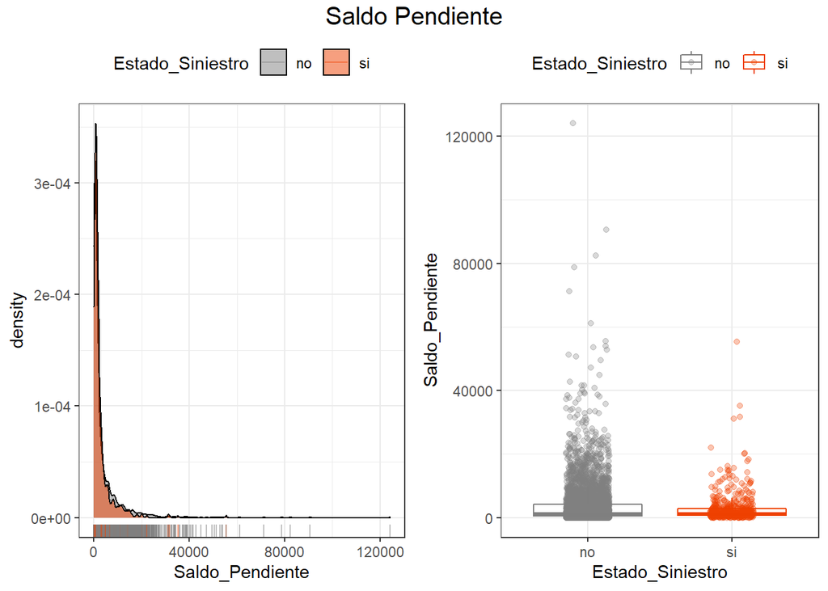

```r
# if (require("ggplot2")) install.packages("ggplot2")
# if (require("ggpubr")) install.packages("ggpubr")
library(ggplot2)
library(ggpubr)
p1 <- ggplot(data = DatosSegurosModelo, aes(x = Saldo_Pendiente, fill = Estado_Siniestro)) +
      geom_density(alpha = 0.5) +
      scale_fill_manual(values = c("gray50", "orangered2")) +
      geom_rug(aes(color = Estado_Siniestro), alpha = 0.5) +
      scale_color_manual(values = c("gray50", "orangered2")) +
      theme_bw()
p2 <- ggplot(data = DatosSegurosModelo, aes(x = Estado_Siniestro, y = Saldo_Pendiente, color = Estado_Siniestro)) +
      geom_boxplot(outlier.shape = NA) +
      geom_jitter(alpha = 0.3, width = 0.15) +
      scale_color_manual(values = c("gray50", "orangered2")) +
      theme_bw()
final_plot <- ggarrange(p1, p2, legend = "top")
final_plot <- annotate_figure(final_plot, top = text_grob("Saldo Pendiente", size = 15))
final_plot
```

###### **Estado_Siniestro vs Saldo_Pendiente_Seg**

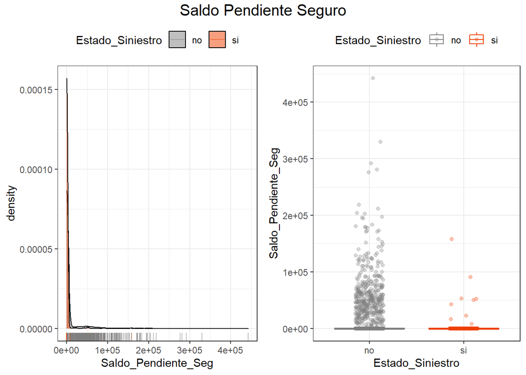

```r
# if (require("ggplot2")) install.packages("ggplot2")
# if (require("ggpubr")) install.packages("ggpubr")
library(ggplot2)
library(ggpubr)
p1 <- ggplot(data = DatosSegurosModelo, aes(x = Saldo_Pendiente_Seg, fill = Estado_Siniestro)) +
      geom_density(alpha = 0.5) +
      scale_fill_manual(values = c("gray50", "orangered2")) +
      geom_rug(aes(color = Estado_Siniestro), alpha = 0.5) +
      scale_color_manual(values = c("gray50", "orangered2")) +
      theme_bw()
p2 <- ggplot(data = DatosSegurosModelo, aes(x = Estado_Siniestro, y = Saldo_Pendiente_Seg, color = Estado_Siniestro)) +
      geom_boxplot(outlier.shape = NA) +
      geom_jitter(alpha = 0.3, width = 0.15) +
      scale_color_manual(values = c("gray50", "orangered2")) +
      theme_bw()
final_plot <- ggarrange(p1, p2, legend = "top")
final_plot <- annotate_figure(final_plot, top = text_grob("Saldo Pendiente Seguro", size = 15))
final_plot
```

###### **Estado_Siniestro vs Siniestros1**

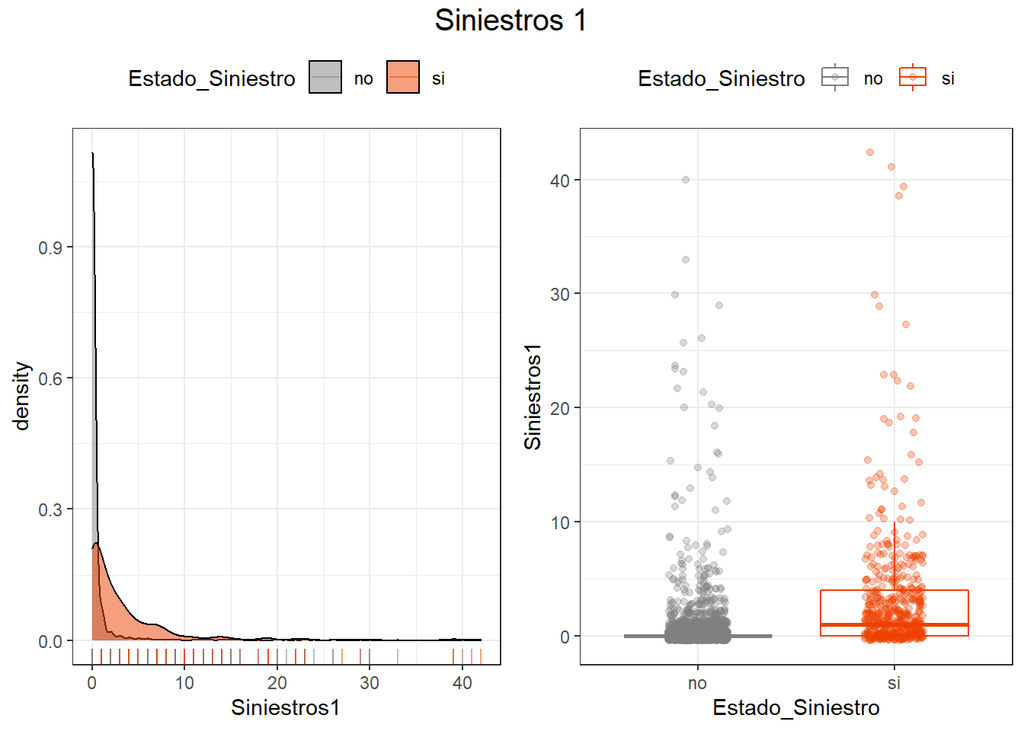

```r
# if (require("ggplot2")) install.packages("ggplot2")
# if (require("ggpubr")) install.packages("ggpubr")
library(ggplot2)
library(ggpubr)
p1 <- ggplot(data = DatosSegurosModelo, aes(x = Siniestros1, fill = Estado_Siniestro)) +
      geom_density(alpha = 0.5) +
      scale_fill_manual(values = c("gray50", "orangered2")) +
      geom_rug(aes(color = Estado_Siniestro), alpha = 0.5) +
      scale_color_manual(values = c("gray50", "orangered2")) +
      theme_bw()
p2 <- ggplot(data = DatosSegurosModelo, aes(x = Estado_Siniestro, y = Siniestros1, color = Estado_Siniestro)) +
      geom_boxplot(outlier.shape = NA) +
      geom_jitter(alpha = 0.3, width = 0.15) +
      scale_color_manual(values = c("gray50", "orangered2")) +
      theme_bw()
final_plot <- ggarrange(p1, p2, legend = "top")
final_plot <- annotate_figure(final_plot, top = text_grob("Siniestros 1", size = 15))
final_plot
```

#### **Versus Variables Categóricas**

###### **Estado_Siniestro vs Nivel_Ingresos**

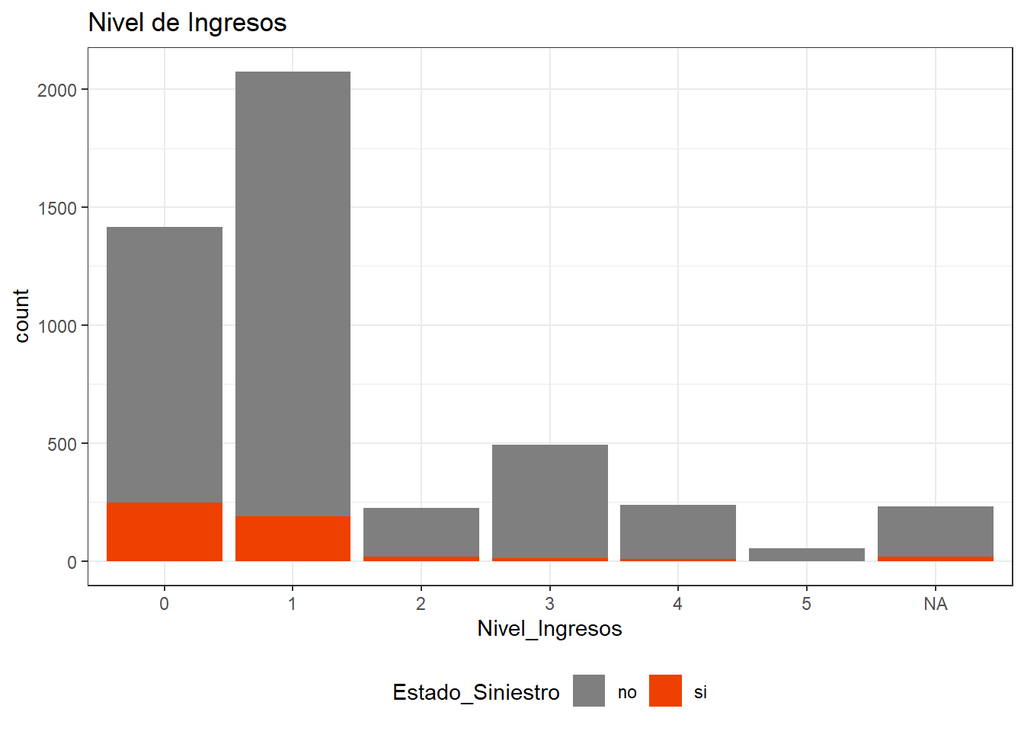

```r
# if (require("ggplot2")) install.packages("ggplot2")
# if (require("ggpubr")) install.packages("ggpubr")
library(ggplot2)
library(ggpubr)
ggplot(data = DatosSegurosModelo, aes(x = Nivel_Ingresos, y = ..count.., fill = Estado_Siniestro)) +
  geom_bar() +
  scale_fill_manual(values = c("gray50", "orangered2")) +
  labs(title = "Nivel de Ingresos") +
  theme_bw() +
  theme(legend.position = "bottom")
```

###### **Estado_Siniestro vs Puntaje_Morosidad1*

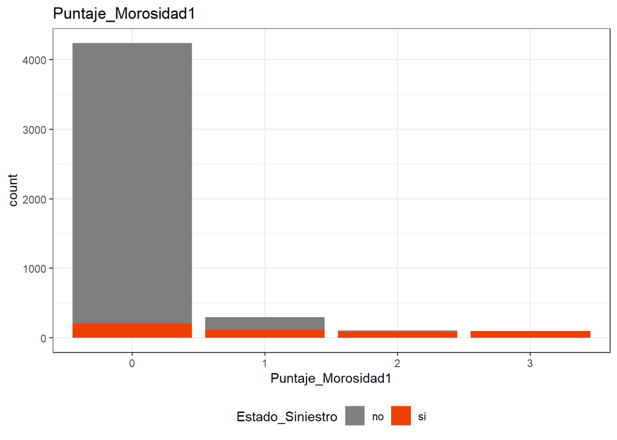

```r
# if (require("ggplot2")) install.packages("ggplot2")
# if (require("ggpubr")) install.packages("ggpubr")
library(ggplot2)
library(ggpubr)
ggplot(data = DatosSegurosModelo, aes(x = Puntaje_Morosidad1, y = ..count.., fill = Estado_Siniestro)) +
  geom_bar() +
  scale_fill_manual(values = c("gray50", "orangered2")) +
  labs(title = "Puntaje_Morosidad1") +
  theme_bw() +
  theme(legend.position = "bottom")
```

## Estadística Inferencial

Como hemos podido observar de acuerdo a los gráficos y frecuencias anteriormente calculados, es muy difícil que tengamos variables con distribución normal. Muchas de las variables que hemos encontrado son sesgadas (Antigüedad Máxima, Saldo Pendiente, Saldo Pendiente Seguro) y otras están concentradas en sólo algunos niveles de variables cualitativas, lo que hace necesario unir algunos niveles y poder realizar algunas pruebas estadísticas que encuentren alguna asociación o relación con nuestra variable target Estado de Siniestro.

### **1. Pruebas de Normalidad**

Ho: Los datos están normalmente distribuidos. Ha: Los datos no están normalmente distribuidos.

#### **Comprobamos que las variables contínuas Antigüeda Máxima, Saldo Pendiente, Saldo Pendiente Seguro y SiniestrosX no tienen distribución normal**

```r
# Test: Kolmogorov-Smirnov "para la prueba de normalidad, n>50 casos"
library(nortest)
lillie.test(DatosSegurosModelo$Antigüedad_Maxima)$p.value
```

```
## [1] 2.862152e-269
```

```r
lillie.test(DatosSegurosModelo$Saldo_Pendiente)$p.value
```

```
## [1] 0
```

```r
lillie.test(DatosSegurosModelo$Saldo_Pendiente_Seg)$p.value
```

```
## [1] 0
```

```r
lillie.test(DatosSegurosModelo$Siniestros1)$p.value
```

```
## [1] 0
```

```r
lillie.test(DatosSegurosModelo$Siniestros2)$p.value
```

```
## [1] 0
```

```r
lillie.test(DatosSegurosModelo$Siniestros3)$p.value
```

```
## [1] 0
```

```r
lillie.test(DatosSegurosModelo$Siniestros4)$p.value
```

```
## [1] 0
```

```r
lillie.test(DatosSegurosModelo$Siniestros5)$p.value
```

```
## [1] 0
```

```r
lillie.test(DatosSegurosModelo$Siniestros6)$p.value
```

```
## [1] 0
```

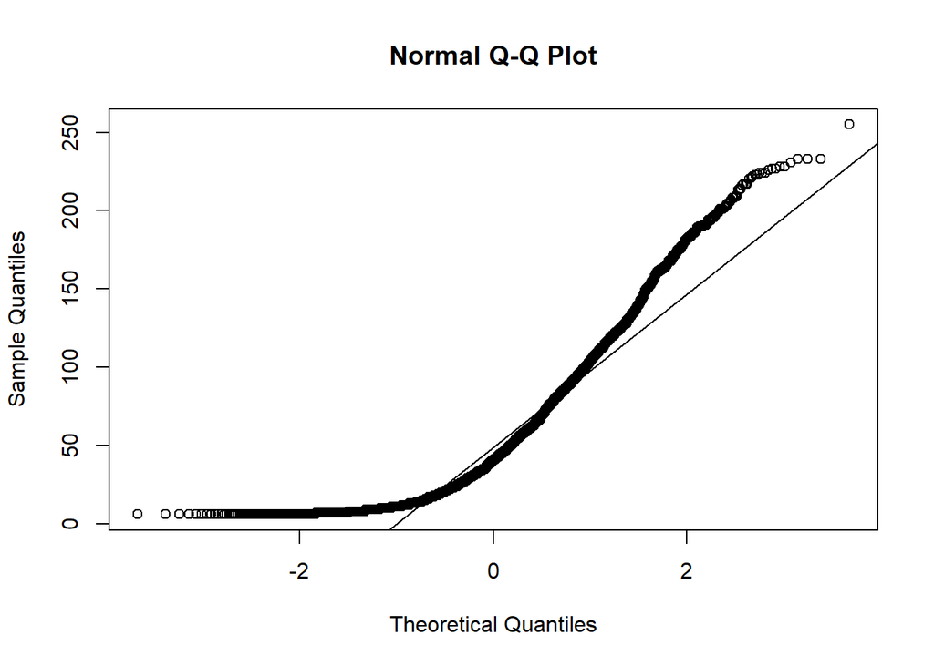

```r
qqnorm(DatosSegurosModelo$Antigüedad_Maxima)
qqline(DatosSegurosModelo$Antigüedad_Maxima)
```

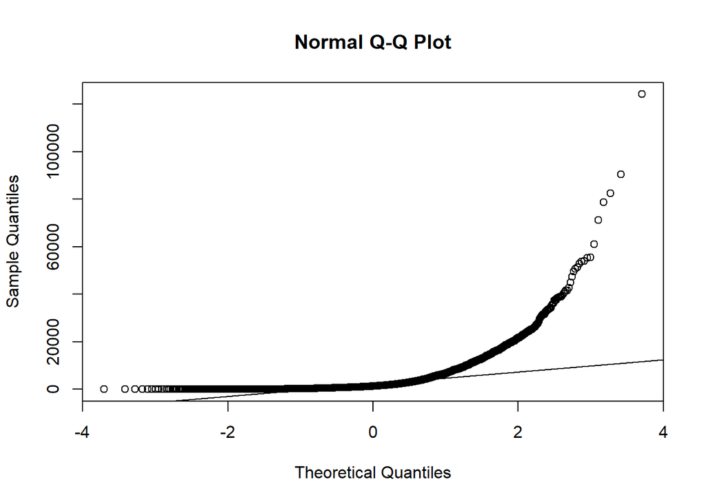

```r
qqnorm(DatosSegurosModelo$Saldo_Pendiente)
qqline(DatosSegurosModelo$Saldo_Pendiente)
```

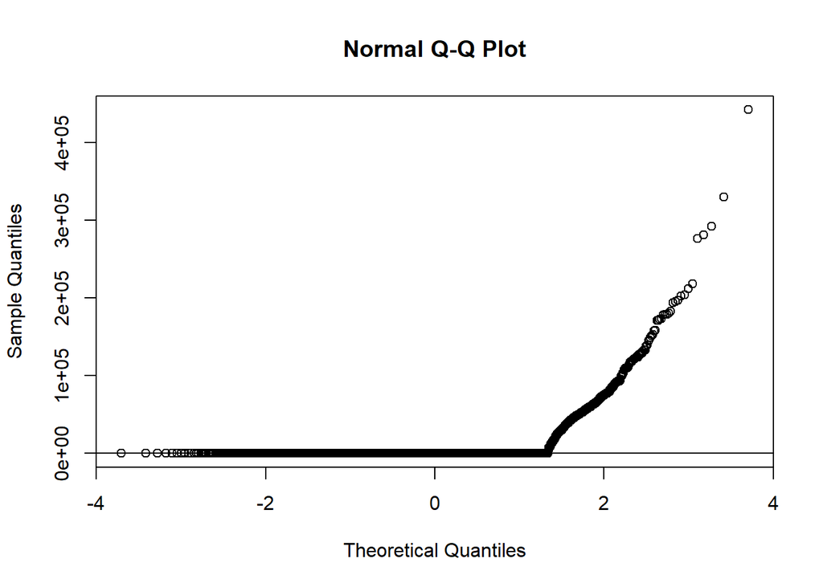

```r
qqnorm(DatosSegurosModelo$Saldo_Pendiente_Seg)
qqline(DatosSegurosModelo$Saldo_Pendiente_Seg)
```

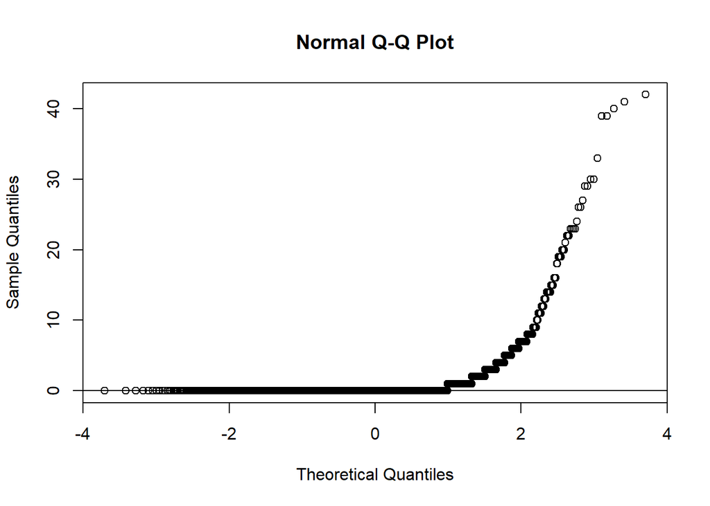

```r
qqnorm(DatosSegurosModelo$Siniestros1)
qqline(DatosSegurosModelo$Siniestros1)
```

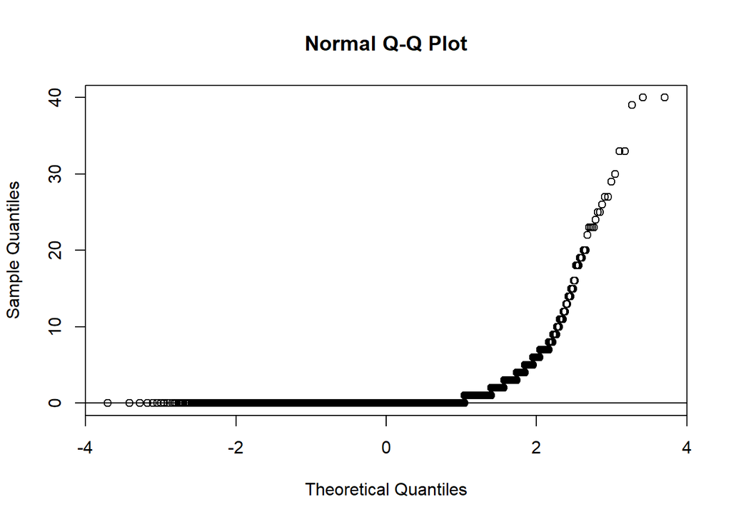

```r
qqnorm(DatosSegurosModelo$Siniestros2)
qqline(DatosSegurosModelo$Siniestros2)
```

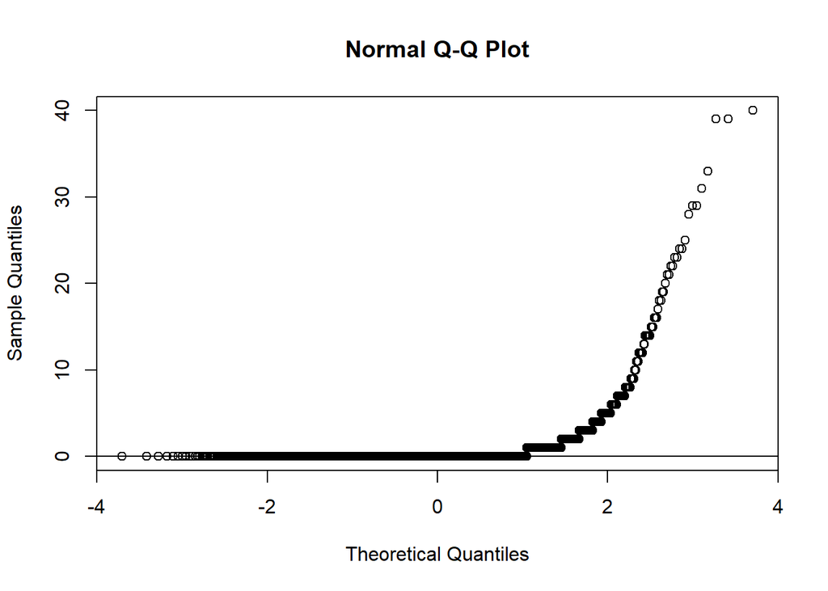

```r
qqnorm(DatosSegurosModelo$Siniestros3)
qqline(DatosSegurosModelo$Siniestros3)
```

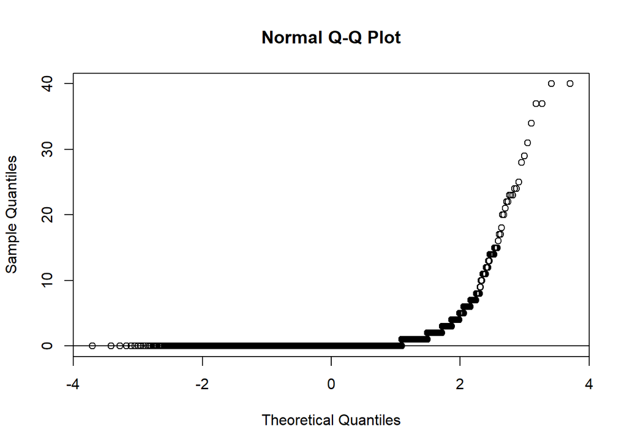

```r
qqnorm(DatosSegurosModelo$Siniestros4)
qqline(DatosSegurosModelo$Siniestros4)
```

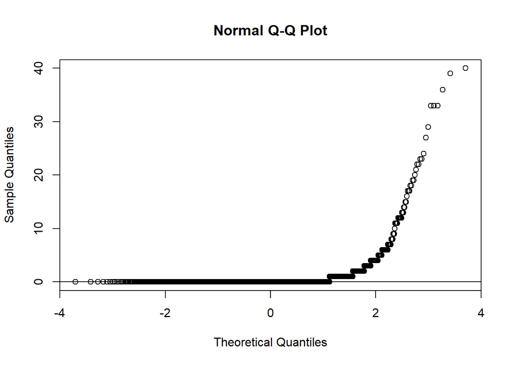

```r
qqnorm(DatosSegurosModelo$Siniestros5)
qqline(DatosSegurosModelo$Siniestros5)
```

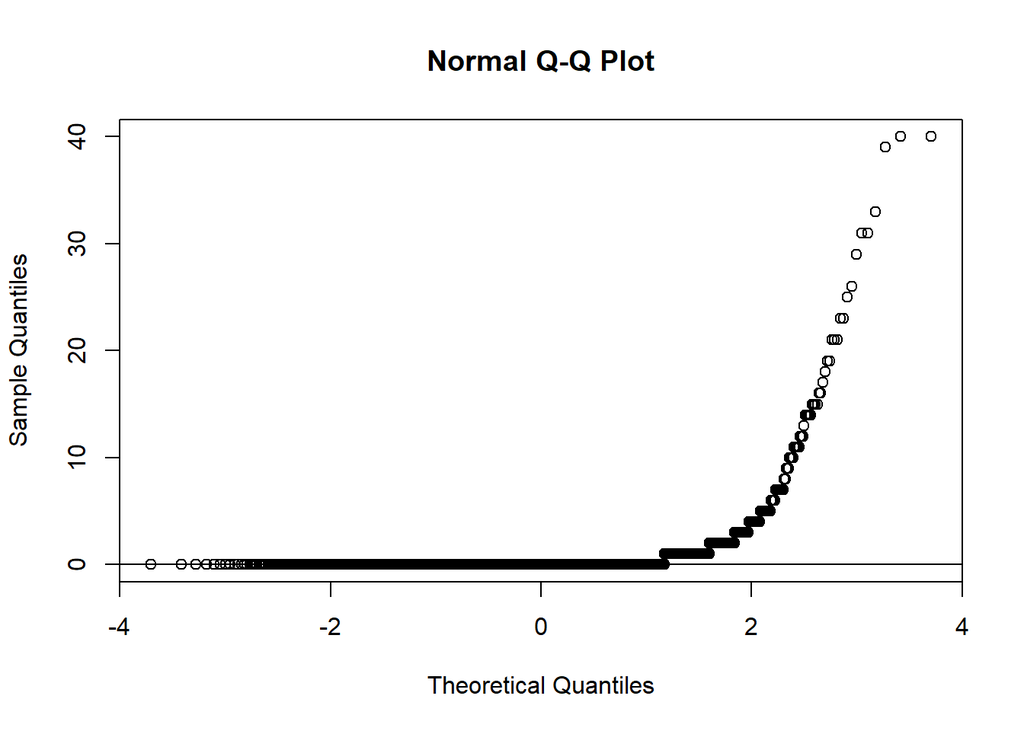

```r
qqnorm(DatosSegurosModelo$Siniestros6)
qqline(DatosSegurosModelo$Siniestros6)
```

**Antiguedad Máxima** **Decisión:** Los datos de la variable no están normalmente distribuidos (p-value: 2.862152e-269); considerando un nivel de confianza del 95% o nivel de significancia del 5%.

**Saldo Pendiente** **Decisión:** Los datos de la variable no están normalmente distribuidos (p-value: 0); considerando un nivel de confianza del 95% o nivel de significancia del 5%.

**Saldo Pendiente Seguro** **Decisión:** Los datos de la variable no están normalmente distribuidos (p-value: 0); considerando un nivel de confianza del 95% o nivel de significancia del 5%.

**Siniestros** **Decisión:** Los datos de la variables SiniestrosX no están normalmente distribuidos (p-value: 0); considerando un nivel de confianza del 95% o nivel de significancia del 5%.

#### **Tampoco se vuelven normales haciendo una transformación (ejemplo raíz cuadrada):**

```r
# Test: Kolmogorov-Smirnov "para la prueba de normalidad, n>50 casos"
library(nortest)
lillie.test(sqrt(DatosSegurosModelo$Antigüedad_Maxima))$p.value
```

```
## [1] 1.73799e-78
```

```r
lillie.test(sqrt(DatosSegurosModelo$Saldo_Pendiente))$p.value
```

```
## [1] 1.874538e-238
```

```r
lillie.test(sqrt(DatosSegurosModelo$Saldo_Pendiente_Seg))$p.value
```

```
## [1] 0
```

```r
lillie.test(sqrt(DatosSegurosModelo$Siniestros1))$p.value
```

```
## [1] 0
```

```r
lillie.test(sqrt(DatosSegurosModelo$Siniestros2))$p.value
```

```
## [1] 0
```

```r
lillie.test(sqrt(DatosSegurosModelo$Siniestros3))$p.value
```

```
## [1] 0
```

```r
lillie.test(sqrt(DatosSegurosModelo$Siniestros4))$p.value
```

```
## [1] 0
```

```r
lillie.test(sqrt(DatosSegurosModelo$Siniestros5))$p.value
```

```
## [1] 0
```

```r
lillie.test(sqrt(DatosSegurosModelo$Siniestros6))$p.value
```

```
## [1] 0
```

### **2. Correlación No Paramétrica: Rho de Spearman**

Ho: Las variables A y B son mutuamente independientes. Ha: Las variables A y B son mutuamente dependientes.

#### **Comprobamos que de las variables contínuas Antigüeda Máxima, Saldo Pendiente, Saldo Pendiente Seguro y Siniestros1, solo Saldo_Pendiente y Siniestros1 son mutuamente independientes, las demás combinaciones de 2 en 2 son mutuamente dependientes**

#### **Comprobaremos si existe algún grado de asociación entre las variables mencionadas:**

```r
library(statsr)
cor.test(DatosSegurosModelo$Saldo_Pendiente, DatosSegurosModelo$Saldo_Pendiente_Seg, method = 'spearman')
```

```
##
##  Spearman's rank correlation rho
##
## data:  DatosSegurosModelo$Saldo_Pendiente and DatosSegurosModelo$Saldo_Pendiente_Seg
## S = 1.4726e+10, p-value < 2.2e-16
## alternative hypothesis: true rho is not equal to 0
## sample estimates:
##       rho
## 0.1661189
```

```r
cor.test(DatosSegurosModelo$Saldo_Pendiente, DatosSegurosModelo$Antigüedad_Maxima, method = 'spearman')
```

```
##
##  Spearman's rank correlation rho
##
## data:  DatosSegurosModelo$Saldo_Pendiente and DatosSegurosModelo$Antigüedad_Maxima
## S = 1.1363e+10, p-value = 2.603e-13
## alternative hypothesis: true rho is not equal to 0
## sample estimates:
##       rho
## 0.1118641
```

```r
cor.test(DatosSegurosModelo$Saldo_Pendiente, DatosSegurosModelo$Siniestros1, method = 'spearman')
```

```
##
##  Spearman's rank correlation rho
##
## data:  DatosSegurosModelo$Saldo_Pendiente and DatosSegurosModelo$Siniestros1
## S = 1.783e+10, p-value = 0.5073
## alternative hypothesis: true rho is not equal to 0
## sample estimates:
##         rho
## -0.00964183
```

```r
cor.test(DatosSegurosModelo$Saldo_Pendiente_Seg, DatosSegurosModelo$Antigüedad_Maxima, method = 'spearman')
```

```
##
##  Spearman's rank correlation rho
##
## data:  DatosSegurosModelo$Saldo_Pendiente_Seg and DatosSegurosModelo$Antigüedad_Maxima
## S = 1.1003e+10, p-value < 2.2e-16
## alternative hypothesis: true rho is not equal to 0
## sample estimates:
##       rho
## 0.1400135
```

```r
cor.test(DatosSegurosModelo$Saldo_Pendiente_Seg, DatosSegurosModelo$Siniestros1, method = 'spearman')
```

```
##
##  Spearman's rank correlation rho
##
## data:  DatosSegurosModelo$Saldo_Pendiente_Seg and DatosSegurosModelo$Siniestros1
## S = 1.9043e+10, p-value = 6.906e-08
## alternative hypothesis: true rho is not equal to 0
## sample estimates:
##         rho
## -0.07830755
```

#### ** Saldo_Pendiente y Saldo_Pendiente_Seg**

**Decision:** Son mutuamente dependientes.  
**Conclusión:** Con un nivel de confianza del 95%, se afirma que, existe una correlación positiva muy baja de 0.1661189 = 0.17

#### ** Saldo_Pendiente y Antigüedad_Maxima**

**Decision:** Son mutuamente dependientes.  
**Conclusión:** Con un nivel de confianza del 95%, se afirma que, existe una correlación positiva muy baja de 0.1118641 = 0.11

#### ** Saldo_Pendiente y Siniestros1**

**Decision:** Son mutuamente independientes.  
**Conclusión:** Con un nivel de confianza del 95%, se afirma que, no existe una correlación entre ambas variables

#### ** Saldo_Pendiente_Seg y Antigüedad_Maxima**

**Decision:** Son mutuamente dependientes.  
**Conclusión:** Con un nivel de confianza del 95%, se afirma que, existe una correlación positiva muy baja de 0.1400135 = 0.14

#### ** Saldo_Pendiente_Seg y Siniestros1**

**Decision:** Son mutuamente dependientes.  
**Conclusión:** Con un nivel de confianza del 95%, se afirma que, existe una correlación negativa muy baja de -0.07830755 = -0.08

### **3. Correlación No Paramétrica: Prueba Chi-cuadrada**

Ho: Las variables A y B son mutuamente independientes. Ha: Las variables A y B son mutuamente dependientes.

#### **Deseamos comprobar si existe relación entre el Nivel de ingresos y el Estado de Siniestro. Esto con el fin de poder determinar si estas variables están relacionads y considerar al nivel de ingresos como un posible predictor del Estado de Siniestralidad.**

#### **Comprobaremos si existe algún grado de relación entre las variables Nivel de Ingresos y Estado de Siniestro:**

```r
chisq.test(table(DatosSegurosModelo$Nivel_Ingresos, DatosSegurosModelo$Estado_Siniestro))
```

```
##
##  Pearson's Chi-squared test
##
## data:  table(DatosSegurosModelo$Nivel_Ingresos, DatosSegurosModelo$Estado_Siniestro)
## X-squared = 132.43, df = 5, p-value < 2.2e-16
```

**Decision:** Las variables Nivel de Ingresos y Estado Siniestro son mutuamente dependientes. Con un nivel de confianza del 95%, se afirma que ambas variables están relacionados.

### **4. No Paramétrica: Prueba de Wilcoxon para 2 muestras relacionadas**

Ho: La mediana de las diferencias de cada par de datos es cero. Ha: La mediana de las diferencias de cada par de datos es diferente de cero.

#### **Deseamos comprobar si la mediana de las diferencias del Número de Siniestros en el 1er Periodo y 2do Periodo es diferente de cero.**

#### **Prueba de Wilcoxon:**

```r
wilcox.test(x = DatosSegurosModelo$Siniestros1, y = DatosSegurosModelo$Siniestros2, alternative = "two.sided", mu = 0, paired = TRUE)
```

```
##
##  Wilcoxon signed rank test with continuity correction
##
## data:  DatosSegurosModelo$Siniestros1 and DatosSegurosModelo$Siniestros2
## V = 85454, p-value < 2.2e-16
## alternative hypothesis: true location shift is not equal to 0
```

**Decision:** La mediana de las diferencias del Número de Siniestros en el 1er Periodo y 2do Periodo es diferente de cero.